# Resistance vs. lysogeny: bacterial defense against temperate phages under phage therapy

Aylin & Marika

2026-10-15

## Abstract

Phage therapy is a promising alternative to antibiotics, but bacteria can adapt to phages. This model simulates two bacterial rescue strategies when facing lethal phage pressure: resistance, which is slow, costly and permanent, and lysogeny, which is immediate but can be lost when the dormant phage is induced. Which strategy succeeds, and when? Building on a stochastic evolutionary rescue simulation model that includes phage dynamics, we varied the cost of resistance and the induction probability and recorded how often each simulation ended in extinction, wild-type persistence, resistant or lysogenic dominance, or temporary coexistence. Lysogeny was the most common route to rescue as long as the dormant phage was stable, but it collapsed abruptly above an induction threshold, whereas resistance was less frequent but declined only gradually with its cost. These results suggest that phage therapy is most robust with phages that always kill their host (strictly lytic phages) or whose dormant form is quickly induced and kills the host (readily inducible phages), although resistance can still rescue the population unless it is very costly.

## 1. Introduction: Simulating evolutionary rescue under phage therapy

In this notebook, we are implementing simulations of evolutionary rescue in a bacterial population under phage pressure. The model is based on a single-mutation, discrete-time framework of evolutionary rescue (Bank 2026, Orr 2008) extended by a phage population and a second rescue strategy. Thereby, we apply a theory classically used in conservation biology in medicine (Alexander 2014). As such, the model can be thought of as a simulation of phage therapy. Phage therapy has recently gained renewed interest as an alternative therapy to antibiotics, which is limited by the spread of antibiotic resistances. A major limitation of phage therapy is the adaptation of the pathogenic bacteria to the phages. Adaptation can be very fast and with varied strategies (Karamlou 2025). For this model, phage therapy is understood as a sudden addition of phages to a wild-type bacteria population. As simulated here, two adaptation strategies with different costs can potentially rescue the bacterial population, i.e., render the phage therapy unsuccessful. We want to explore under which conditions the bacterial population is rescued and if so, which strategy is more successful.

## 2. Model and Methods

### Model overview: strategies and outcomes

The model is as follows: a haploid bacterial population starts with a given number of wild-type (wt) bacteria and a fixed growth rate together with a population of free phages. Because of the phages, the wild-type is unfit: in each generation wt bacteria are killed by phage infection and the more phages there are, the higher the death rate of the wild-type. The following are the two possible survival strategies that the bacteria population have:

1. Resistance (slow but safe): wt offspring have a resistance mutation at a low rate (`mut_rate`). Resistant bacteria are immune to the phages and are not killed by infection. Resistance is permanent, but it comes with a fitness cost (`cost_r`) that reduces their offspring number. This strategy is phage-independent.
2. Lysogen (fast but risky): wt bacteria can enter a lysogenic relationship with the phage (`lysogen_prob`), which becomes more likely the more phages are present. Lysogenic bacteria carry a dormant phage and therefore cannot die from infection. However, they can later be killed by induction of the dormant phage (`induction_prob`), which releases new phages into the environment. This strategy is phage-dependent.

Figure 1 shows a schematic of one generation. Not depicted are the rates and probabilities leading to each new population (i.e., `growth_rate`, `mut_rate`, `cost_r`, `lysogen_prob`, `induction_prob`, `infection_prob`, `P_decline`, `P_prod`).

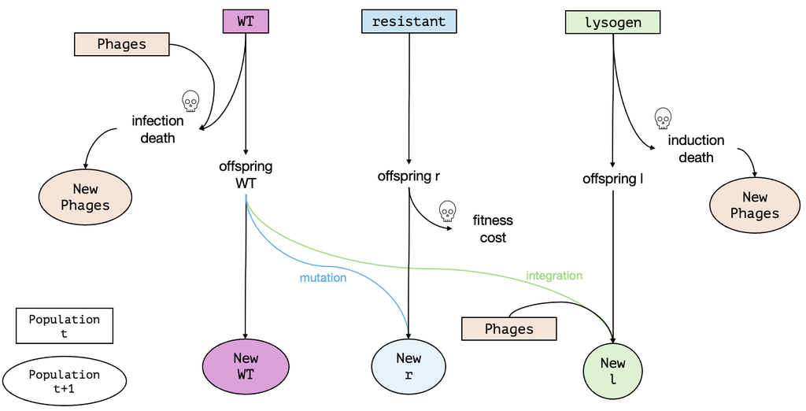

*Figure 1: Life cycle of one generation in the model (from generation t to generation t+1)*

All bacterial types grow with a shared carrying capacity (`K`) and the phage population is updated each generation from phage decline (`P_decline`) and from phage production at infection and induction events (`P_prod`). Resistant and lysogenic bacteria start at a population number of 0, so they have to arise from wt bacteria through mutations or integration (i.e., becoming a lysogen) and then spread before the total bacterial population goes extinct. Rescue means that the bacterial population (be it wt, resistant or lysogen) recovers and persists.

The following are the three possible outcomes of our model: 1. Extinction 2. Only lysogen persists 3. Only resistance persists

### List of variables and parameters

| Name | Type | Description | Allowed range | Value |
| --- | --- | --- | --- | --- |
| $N_{wt}$ | State variable | Current size of the wild-type bacteria population | integer ≥ 0 | changes over time |
| $N_r$ | State variable | Current size of the resistant bacteria population | integer ≥ 0 | changes over time |
| $N_l$ | State variable | Current size of the lysogenic bacteria population | integer ≥ 0 | changes over time |
| $N_P$ | State variable | Current size of the phage population | ≥ 0 | changes over time |
| `N_init_wt` | Initial condition | Initial size of the wild-type population | positive integer | 100 |
| `N_init_r` | Initial condition | Initial size of the resistant mutant population | integer ≥ 0 | 0 |
| `N_init_l` | Initial condition | Initial size of the lysogenic population | integer ≥ 0 | 0 |
| `N_init_P` | Initial condition | Initial size of the phage population | positive integer | 1 |
| `growth_rate` | Model parameter | Average number of offspring per bacterium (wt, r and l) per generation | ≥ 0 | 1.5 |
| `lysogen_prob` | Model parameter | Probability that a wt bacterium becomes lysogenic | 0 to 1 | 0.002 |
| `mut_rate` | Model parameter | Probability that an offspring of a wt bacterium mutates to resistant | 0 to 1 | 0.002 |
| `infection_prob` | Model parameter | Probability that a wt bacterium is infected by a phage per generation | 0 to 1 | 0.01 |
| `K` | Model parameter | Carrying capacity of the total bacteria population (wt + r + l) | positive integer | 2000 |
| `P_decline` | Model parameter | Fraction of phages decaying every generation (entered as a negative number) | ≤ 0 | -0.5 |
| `P_prod` | Model parameter | Number of new phages produced per infection or induction | ≥ 0 | 1.5 |
| `t_max` | Simulation setting | Number of generations after which the simulation stops (not a model parameter). The simulation also stops automatically if the bacterial population goes extinct | integer > 0 | 2000 |
| `induction_prob` | Varied parameter | Probability (per generation) that a lysogenic bacterium is killed by its own dormant phage | 0 to 1 | varied in the analysis |
| `cost_r` | Varied parameter | Fraction of offspring that resistant bacteria lose compared to wt (fitness cost of resistance) | 0 to 1 | varied in the analysis |

### R setup

Run this chunk to ensure you have all needed packages. Enter your local path name to the downloaded GitHub repository to access the saved simulation data. Data with the parameters set in the code is provided for all analysis/simulation plots (for each plot, the data is fetched from the repository with a corresponding date of creation). All simulation/iteration code chunks are set at `eval = F` to avoid the time-consuming simulations. If you want to run your own simulations with e.g., changed parameters, 1. set `eval = T` for the simulation chunk and 2. change the date for fetching the data to Sys.Date() or to the date you ran your simulations.

### Simulate one generation of population size change

We want to follow the numbers of wild-type, resistant and lysogenic bacteria over time, as well as the phage population. As a first step, we simulate a single generation. At generation $t$, the population consists of $N_{wt}$ wild-type bacteria, $N_r$ resistant bacteria, $N_l$ lysogens and $N_p$ phages. One generation consists of three steps:

1. **Expected offspring.** Each bacterial type has its own net growth rate, which is the intrinsic growth rate (`growth_rate`, same for all bacterial types) minus a type-specific loss. For wild-type bacteria the loss is the infection probability multiplied by the number of phages, so the more phages there are, the higher the death rate. For resistant bacteria the loss is the cost of resistance (`cost_r`), and for lysogens it is the induction probability (`induction_prob`). Crowding, set by the carrying capacity $K$, reduces the growth of all three types by the same amount. The number of offspring of each type is then drawn from a Poisson distribution around its expected value.
2. **Mutation and lysogen.** The wild-type offspring are divided into three groups with a multinomial draw: they become resistant (probability `mut_rate`), become lysogenic (probability `lysogen_prob` multiplied by $N_p$, since more phages make it more likely that a wild-type bacterium becomes lysogen), or remain wild type (the remaining probability).
3. **Phage dynamics.** The phage population declines by a fixed fraction (`P_decline`) and gains `P_prod` new phages for each infection of a wild-type bacterium and each induction of a lysogen.

The result of these steps gives the sizes of all bacterial populations and of the phage population at generation $t+1$.

```r
simulate_one_gen <- function(N_wt, N_r, N_l, N_p, infection_prob, induction_prob, lysogen_prob, mut_rate, cost_r, growth_rate, K, P_decline, P_prod) {

  N_tot <- N_wt + N_r + N_l

  # intrinsic growth without losses
  r0 <- growth_rate - 1

  # growth rate of each type minus its specific loss
  rho_wt <- r0 - infection_prob * N_p # includes phage population effect
  rho_r <- r0 - cost_r
  rho_l <- r0 - induction_prob

  # logistic growth: crowding reduces all types by the same amount --> note that deleterious effect is less strong on wt at lower density --> could exist longer at lower K
  mean_wt <- N_wt * max(0, 1 + rho_wt - r0 * N_tot / K)
  mean_r <- N_r * max(0, 1 + rho_r - r0 * N_tot / K)
  mean_l <- N_l * max(0, 1 + rho_l - r0 * N_tot / K)

  # 1. expected offspring (Poisson)
  offsp_wt <- rpois(1, mean_wt)
  offsp_r  <- rpois(1, mean_r)
  offsp_l  <- rpois(1, mean_l)

  # 2. wt bacteria (offspring) either get infected (& die) or do lysogen or stay (multinomial)
  prob_r = mut_rate
  prob_l = min(lysogen_prob * N_p, 1 - prob_r) # includes phage population effect
  prob_wt <- max(0,1 - prob_r - prob_l)

  outcome <- rmultinom(1,offsp_wt,c(prob_r, prob_l, prob_wt))

  n_resistant <- outcome[1]
  n_lysogenic <- outcome[2]
  n_wt <- outcome[3]

  #new population sizes of wild type, resistant and lysogens
  N_wt_new <- n_wt
  N_r_new  <- offsp_r + n_resistant
  N_l_new  <- offsp_l + n_lysogenic

  # 3. phage population dynamics
  infections = min(N_wt, infection_prob * N_p * N_wt)
  inductions = induction_prob * N_l
  P_new = N_p * (1 + P_decline) + P_prod * (infections + inductions)

  return(c(N_wt_new, N_r_new, N_l_new, P_new))
}


# Test the function
# N_wt <- 1000
# N_r <- 0
# N_l <- 0
# N_p <- 5
# infection_prob <- 0.01
# induction_prob <- 0.55
# lysogen_prob <-0.002
# cost_r <- 0.55
# growth_rate <- 1.5
# mut_rate <- 0.002
# K <- 2000
# P_decline <- -0.5
# P_prod <- 1.5
#
# print(simulate_one_gen(N_wt, N_r, N_l, N_p, infection_prob, induction_prob, lysogen_prob, mut_rate, cost_r, growth_rate, K, P_decline, P_prod))
```

### Simulate a population trajectory

We can now track the dynamics of the population from one generation to the next, but this is not enough. We want to follow the bacteria and phages from time 0 until the bacteria population either goes extinct or has been rescued by resistant or lysogenic bacteria. The following function repeats the one generation step up to `t_max` times and stores the sizes of the wild-type, resistant and lysogenic bacteria populations and of the phages in every generation. The simulation stops early if all bacteria (wt,r,l) have died. A population trajectory with the outcome of resistance persisting is included for illustration purposes. The parameters are the set model parameters (see *List of variables and parameters*), `induction_prob` = 0.48 and `cost_r`= 0.35. `t_max` is set at 200 for better resolution (Figure 2). Examples of different outcome scenarios are provided in Supplementary Figures 1-4.

```r
simulate_pop <- function(N_init_wt, N_init_r, N_init_l, N_init_p, infection_prob, induction_prob, lysogen_prob, mut_rate, cost_r, growth_rate, t_max, K, P_decline, P_prod) {


  # Create the vector in which to save the results
  pop_vector <- c(N_init_wt, N_init_r, N_init_l, N_init_p)
  # initiate the variables
  pop_new <- c(N_init_wt, N_init_r, N_init_l, N_init_p)

  # run the simulation until generation t_max
  for (i in 1:t_max) {
    # redefine the current population one generation later
    pop_new <- simulate_one_gen(pop_new[1],pop_new[2], pop_new[3], pop_new[4], infection_prob, induction_prob, lysogen_prob, mut_rate, cost_r, growth_rate, K, P_decline, P_prod)
    # add the new population sizes to the output vector
    pop_vector <- rbind(pop_vector,pop_new)
    # condition to stop the simulation before t_max: the bacteria population goes extinct
    if (pop_new[1]+pop_new[2]+pop_new[3]==0) break
  }

  # define the row and column names of the output vector
  rownames(pop_vector) <- (0:t_max)[1:length(pop_vector[,1])] # note that the vector has to be cut if the simulation stopped early
  colnames(pop_vector) <- c("wt","r", "l", "p")
  # return the result
  return(pop_vector)
}
```

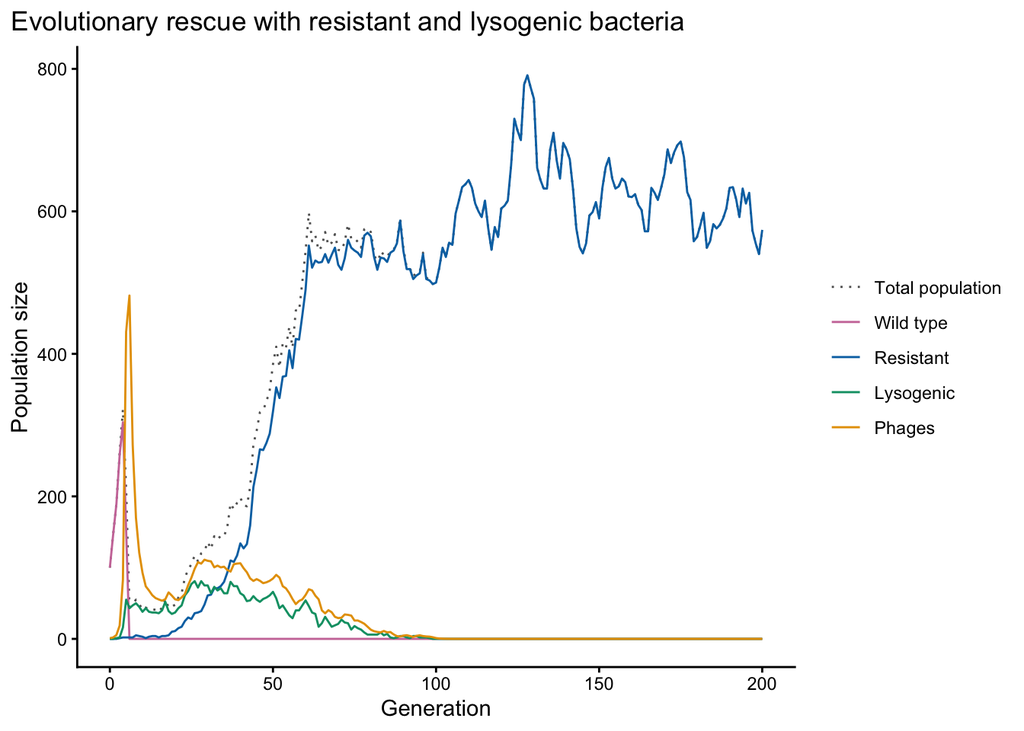

*Figure 2: Population trajectories with both resistant and lysogen strategies with set model parameters (see model overview), `induction_prob` = 0.48 and `cost_r`= 0.35. `t_max`is set at 200 for better resolution. Here, the outcome would be resistance persisting.*

## 3. Analysis

### Varying induction_prob and cost_r

1. Extinction: the total bacterial population (wt + r + l) goes extinct
2. Resistance: wt and l go extinct, r remains
3. Lysogen: wt and r go extinct, l remains
4. Temporary coexistence
5. Wildtype: wt never goes extinct

The outcome “Temporary coexistence” is a category in our analysis when neither l or r have gone extinct by the end of the simulation (i.e., after `t_max`generations). Running these cases with longer `t_max`showed that there is in fact no coexistence between r and l but one of the two was declining and had not yet reached a population size of 0 by the end of the simulation. As such, it is an issue of too small `t_max` and not a final outcome of the model. This category is included as an outcome to avoid errors if this case occurs. The outcome “Wildtype” (i.e., the survival of the wild-type population) is not possible with the set parameters. The outcome “Wildtype” is however included in the code to enable simulations with parameters where the wild-type population could subsist.

```
##      induction_prob cost_r wt r    l        p seed
## [1,]           0.05   0.05  0 0 1810 272.7906    2
## [2,]           0.05   0.05  0 0 1701 264.3569    3
## [3,]           0.05   0.05  0 0 1845 270.6615    4
## [4,]           0.05   0.05  0 0 1776 266.4013    5
## [5,]           0.05   0.05  0 0 1871 258.6237    6
## [6,]           0.05   0.05  0 0 1730 273.1342    7
```

```
##   induction_prob cost_r wt r    l        p seed outcome
## 1           0.05   0.05  0 0 1810 272.7906    2  l wins
## 2           0.05   0.05  0 0 1701 264.3569    3  l wins
## 3           0.05   0.05  0 0 1845 270.6615    4  l wins
## 4           0.05   0.05  0 0 1776 266.4013    5  l wins
## 5           0.05   0.05  0 0 1871 258.6237    6  l wins
## 6           0.05   0.05  0 0 1730 273.1342    7  l wins
```

```
##      induction_prob cost_r wt r l         p seed    outcome
## 4895           0.95   0.95  0 0 0 25.573196   96 extinction
## 4896           0.95   0.95  0 0 0 24.868068   97 extinction
## 4897           0.95   0.95  0 0 0 77.602633   98 extinction
## 4898           0.95   0.95  0 0 0 16.990885   99 extinction
## 4899           0.95   0.95  0 0 0 11.950051  100 extinction
## 4900           0.95   0.95  0 0 0  9.080869  101 extinction
```

##### Varying cost_r only

Here, we vary `cost_r` from 0.05 to 0.95 in steps of 0.15 with an `induction_prob` at a fixed value of 0.46. We perform 100 simulations for each value of `cost_r` and record the outcomes (as described above). A corresponding simulation with a fixed `cost_r`and varying `induction_prob` can be seen in Supplementary Figure 5. Simulations and plots of scenarios with no resistance (`mut_rate` = 0) or no lysogeny (`lysogen_prob` = 0) are provided in *9. Supplementary data and figures* (Supplementary Figures 6 and 7).

The tables are saved as csv files so that the plots below can be recreated without re-running the (slow) simulations.

## 4. Results: Effects of varying induction_prob and cost_r on outcomes

The saved data from the simulations run above is read in and visualized. For the combined analysis, the proportion of each outcome (lysogen or resistance) is calculated and show as to heat maps (Figures 3 and 4, respectively. The number in eachtile is the proportion of replicates; from 0 to 1). The heat maps for extinction & survival are shown in Supplementary Figures 8 and 9.

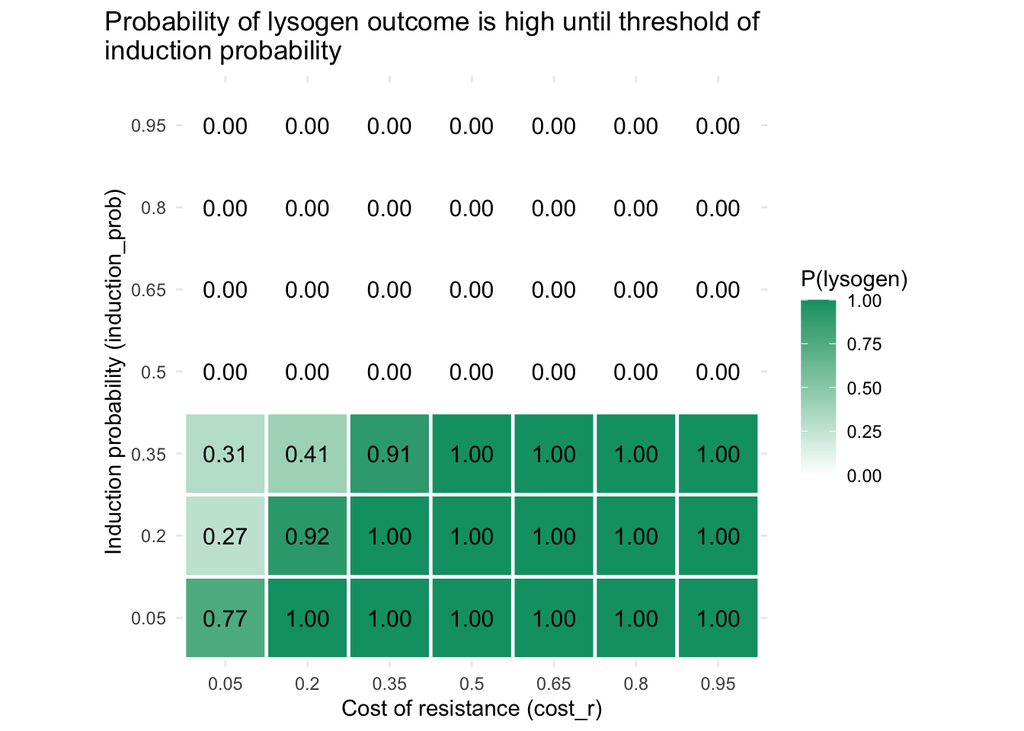

*Figure 3: Heat map of probability that only lysogens (l) remain. 100 simulations of every combination of values for `cost_r` and `induction_prob` ranging from 0.05 to 0.95 (by steps of 0.15) were run. The other model parameters were set as given in the List of variables and parameters (2. Model and Methods). Here, the fractions of simulations out of 100 in which only the lysogen population remained is shown.*

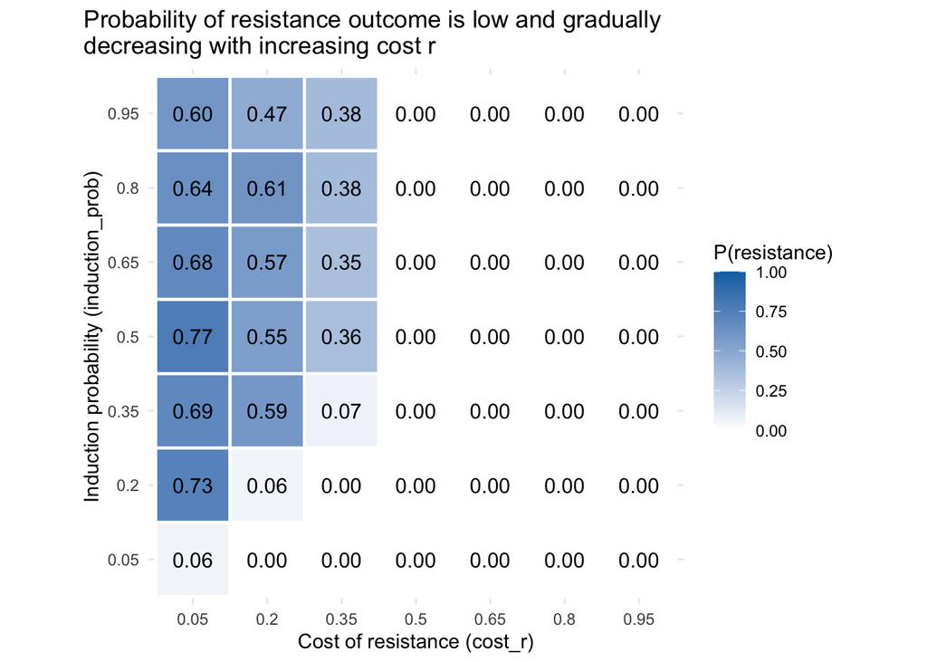

*Figure 4: Heat map of probability that only resistant bacteria (r) remain. 100 simulations of every combination of values for `cost_r` and `induction_prob` ranging from 0.05 to 0.95 (by steps of 0.15) were run. The other model parameters were set as given in the List of variables and parameters (2. Model and Methods). Here, the fractions of simulations out of 100 in which only the resistant population remained is shown.*

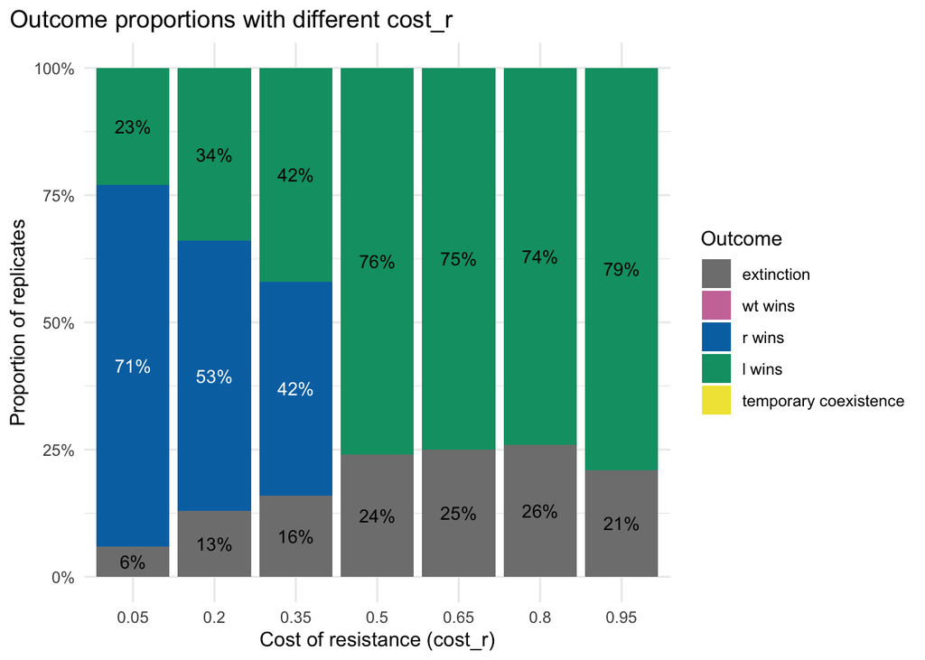

*Figure 5: Barplot of outcome proportions for varying `cost_r` and fixed `induction_prob`. 100 simulations for each `cost_r` increasing from 0.05 to 0.95 (by steps of 0.15), a fixed `induction_prob`= 0.46 and set model parameters (List of variables and parameters in 2. Model and Methods) were run and the outcomes recorded. The percentage of each outcome for each value of `cost_r` is shown.*

## 5. Discussion

### Implications for phage therapy

**1. Temperate phages can protect bacteria instead of killing them.** When the dormant phage is stable (low `induction_prob`), lysogeny was the most common route to rescue (Figure 3). Because integration scales with phage density, adding phages fuels a positive feedback loop (induction, more phages, more integration, more lysogeny). A phage that can integrate may therefore turn the therapeutic agent into a protective element for the bacteria. This is consistent with the general preference for strictly lytic phages in therapy.

### Limitations

Our model is a very simplified depiction of bacteria-phage interactions and isn’t parameterized with empirical data.

## 6. Conclusions

Resistance and lysogeny rescue bacteria in very different ways. Lysogeny is boosted by the phage population, which makes its emergence nearly deterministic instead of stochastic. As long as the dormant phage is stable, lysogeny is therefore the dominant outcome, but it collapses abruptly once induction makes it too costly. Resistance is phage-independent and its success decreases gradually with its cost. As the resistant bacteria emerge stochastically at a fixed probability and are limited by crowding, the resistant outcome never reaches as high proportions as the lysogen. For phage therapy, this points to phages that always kill their host (strictly lytic phages) or whose dormant form is quickly induced and kills the host (readily inducible phages) as the most effective. However, resistance can still rescue the bacterial population unless it is very costly. The value of this model lies in making these mechanisms transparent and in showing which parameters matter. It is however not calibrated to real systems. The conclusions are hypotheses to be tested with more realistic phage dynamics and experiments.

## 7. References

Alexander HK et al. (2014) Evolutionary rescue: linking theory for conservation and medicine. *Evolutionary Applications* 7: 1161-79. DOI: https://doi.org/10.1111/eva.12221

Bank C (2026) Course material: basic evolutionary rescue notebook

Karamlou S et al. (2025) Bacterial resistance to phage therapy: Mechanisms and strategies to overcome it. *Current Molecular Pharmacology* 18: 108-122. DOI: https://doi.org/10.1016/j.cmp.2025.11.003

Orr HA, Unckless RL (2008) Population Extinction and the Genetics of Adaptation. *The American Naturalist* 172(2). DOI:https://doi.org/10.1086/589460

## 8. Declarations

### Author contributions

We worked on most parts together, building on each other’s work.

Individual work:

- Heatmaps: Marika
- Abstract: Aylin

### AI use declaration

Claude and ChatGPT were used on the R code for

- debugging
- implementing concepts in the base code (e.g., carrying capacity)
- generating plots
- RMarkdown layout Furthermore, Claude was used to determine useful parameter ranges.

For debugging and implementing concepts, suggestions from Claude and ChatGPT were not copied as a whole but selective changes were manually made in the code to ensure no unknown changes happened. For visuals (plots and layout), whole code blocks were copied. The outputs were checked visually (i.e., whether they generated what we imagined).

## 9. Supplementary data and figures

### 9.1. Population trajectories with different strategies

Here we plot population trajectories with 1) both strategies, 2) no strategies, 3) only lysogeny (no resistance) and 4) only resistance (no lysogeny) for illustration purposes.

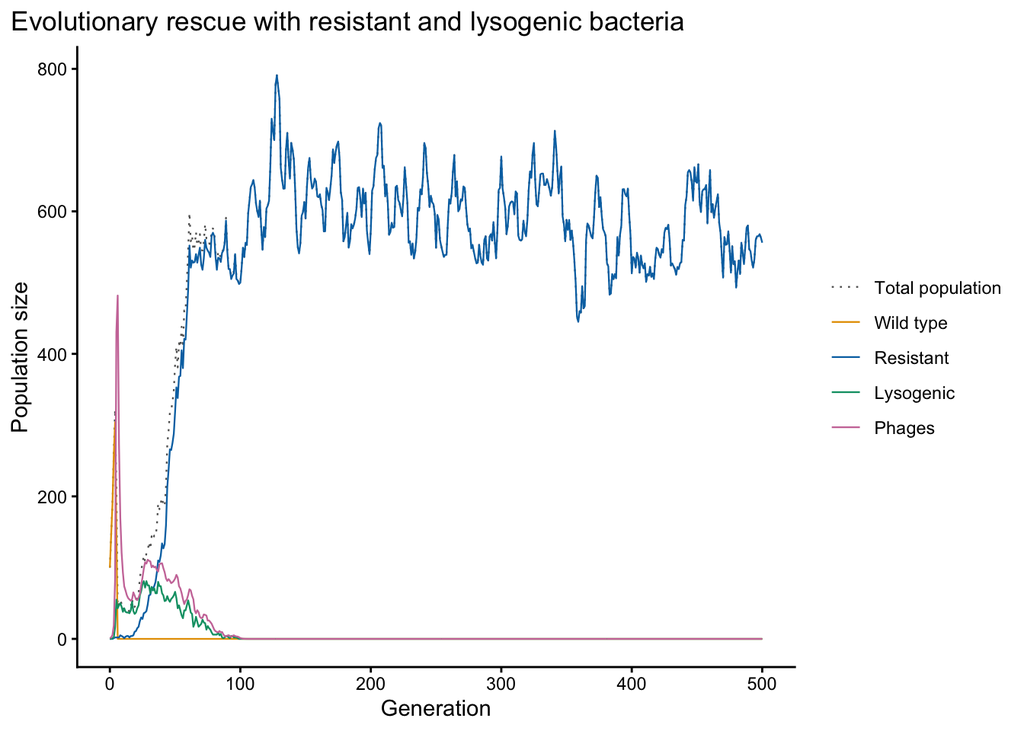

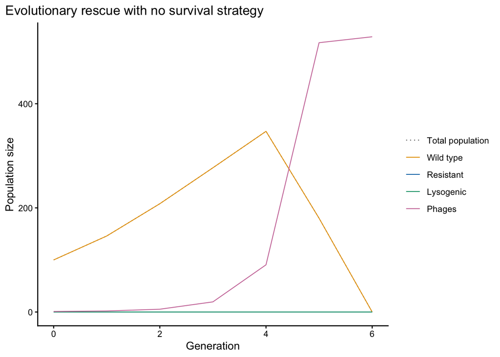

*Supplementary Figure 2: Population trajectories with no survival strategies with set model parameters (see model overview) and `lysogen_prob` = 0 and `mut_rate = 0`*

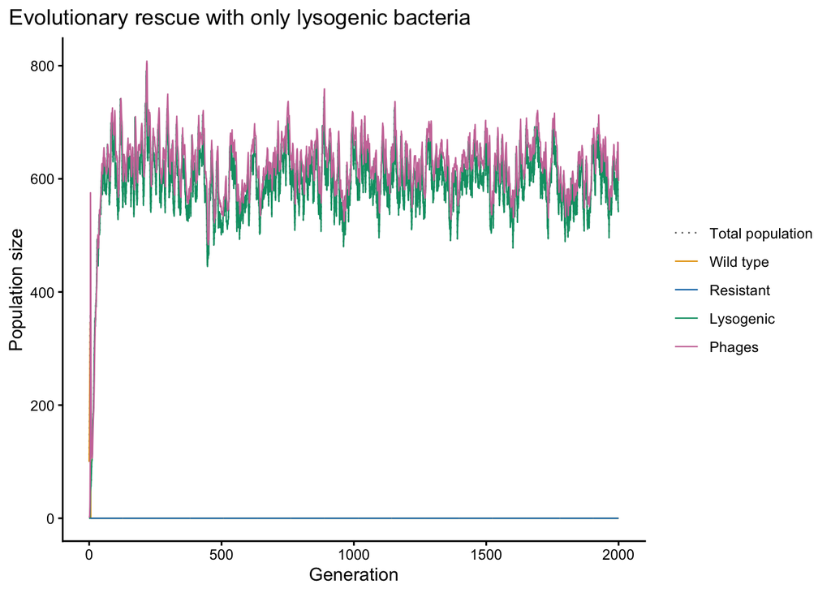

*Supplementary Figure 3: Population trajectories with only lysogenic strategy with set model parameters (see model overview), `lysogen_prob` = 0.002, `mut_rate` = 0 and `induction_prob` = 0.35*

[figure not shown]

*Supplementary Figure 4: Population trajectories with only resistant strategy with set model parameters (see model overview), `lysogen_prob` = 0, `mut_rate` = 0.002 and `cost_r` = 0.35*

### 9.2. Supplementary Analysis:

#### Effects of induction_prob only

```
##      induction_prob wt r    l        p seed
## [1,]           0.05  0 0 1840 271.7810    2
## [2,]           0.05  0 0 1693 254.6909    3
## [3,]           0.05  0 0 1816 271.6409    4
## [4,]           0.05  0 0 1782 272.3564    5
## [5,]           0.05  0 0 1751 267.9265    6
## [6,]           0.05  0 0 1769 273.7828    7
```

```
##   induction_prob wt r    l        p seed outcome
## 1           0.05  0 0 1840 271.7810    2  l wins
## 2           0.05  0 0 1693 254.6909    3  l wins
## 3           0.05  0 0 1816 271.6409    4  l wins
## 4           0.05  0 0 1782 272.3564    5  l wins
## 5           0.05  0 0 1751 267.9265    6  l wins
## 6           0.05  0 0 1769 273.7828    7  l wins
```

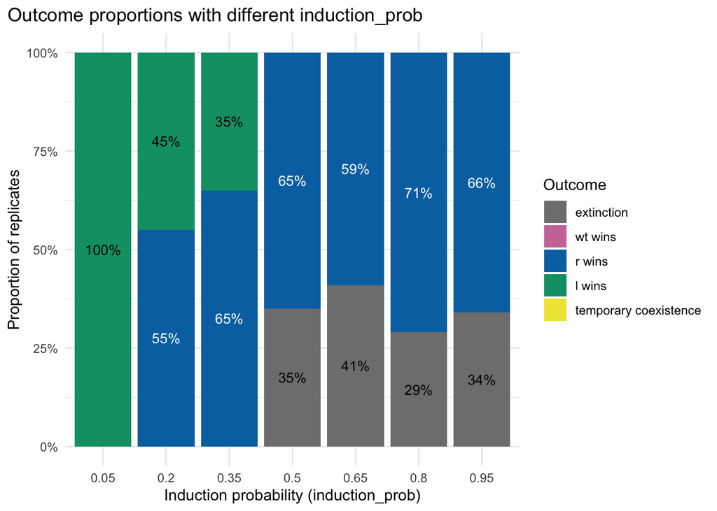

*Supplementary Figure 5: Barplot of outcome proportions of 100 simulation replicates with varying `induction_prob`, `cost_r`= 0.1 and set model parameters (see model overview)*

#### Effects of varying cost_r with no lysogeny

```
##      cost_r wt    r l         p seed
## [1,]   0.05  0    0 0 527.45768    2
## [2,]   0.05  0 1769 0   0.00000    3
## [3,]   0.05  0 1805 0   0.00000    4
## [4,]   0.05  0    0 0 538.40543    5
## [5,]   0.05  0    0 0  35.25729    6
## [6,]   0.05  0 1699 0   0.00000    7
```

```
##   cost_r wt    r l         p seed    outcome
## 1   0.05  0    0 0 527.45768    2 extinction
## 2   0.05  0 1769 0   0.00000    3     r wins
## 3   0.05  0 1805 0   0.00000    4     r wins
## 4   0.05  0    0 0 538.40543    5 extinction
## 5   0.05  0    0 0  35.25729    6 extinction
## 6   0.05  0 1699 0   0.00000    7     r wins
```

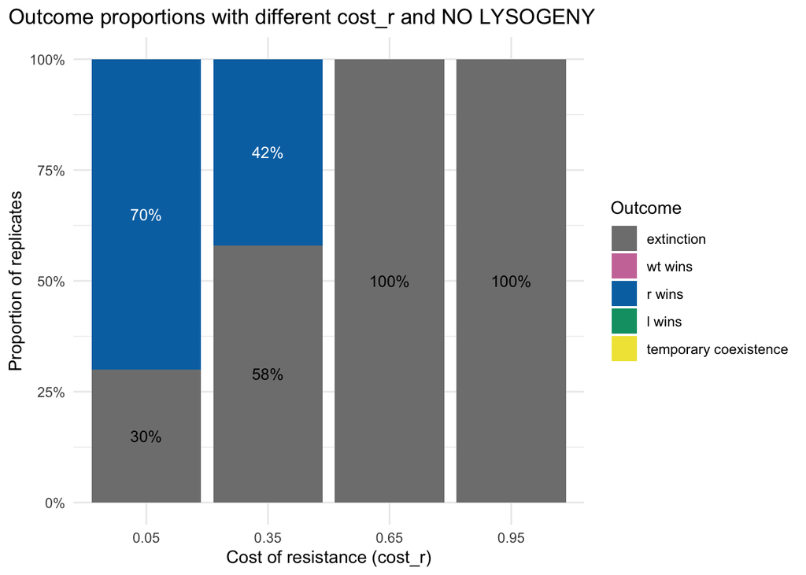

*Supplementary Figure 6: Barplot of outcome proportions of 100 simulation replicates with varying `cost_r`, no lysogeny (`lysogen_prob` = 0) and set model parameters (see model overview)*

#### Effect of varying induction_prob with no resistance

```
##      induction_prob wt r    l        p seed
## [1,]           0.05  0 0 1840 271.7810    2
## [2,]           0.05  0 0 1693 254.6909    3
## [3,]           0.05  0 0 1816 271.6409    4
## [4,]           0.05  0 0 1782 272.3564    5
## [5,]           0.05  0 0 1751 267.9265    6
## [6,]           0.05  0 0 1769 273.7828    7
```

```
##   induction_prob wt r    l        p seed outcome
## 1           0.05  0 0 1840 271.7810    2  l wins
## 2           0.05  0 0 1693 254.6909    3  l wins
## 3           0.05  0 0 1816 271.6409    4  l wins
## 4           0.05  0 0 1782 272.3564    5  l wins
## 5           0.05  0 0 1751 267.9265    6  l wins
## 6           0.05  0 0 1769 273.7828    7  l wins
```

[figure not shown]

### 9.3. Supplementary heat maps of the combined analysis

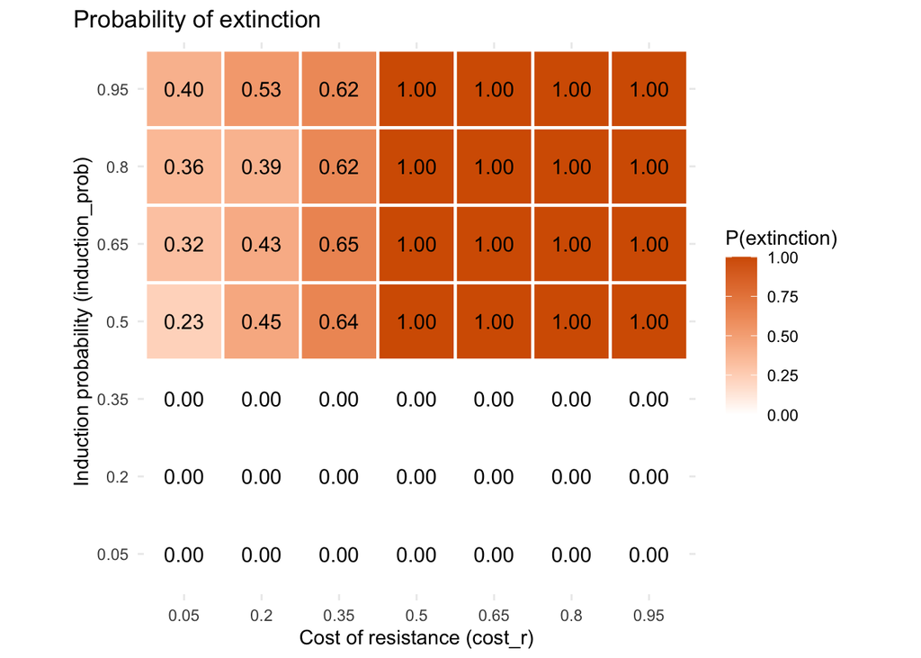

*Supplementary Figure 8: Heat map of probability of extinction of the total population*

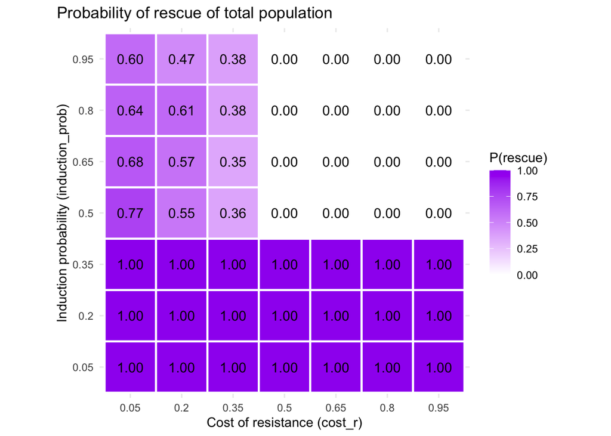

*Supplementary Figure 9: Heat map of probability of survival of the total population (= 1 - extinction; this counts every outcome except extinction, including wt wins and temporary coexistence)*

### 9.4. Supplementary “zoom-in” into varying cost-r and induction_prob

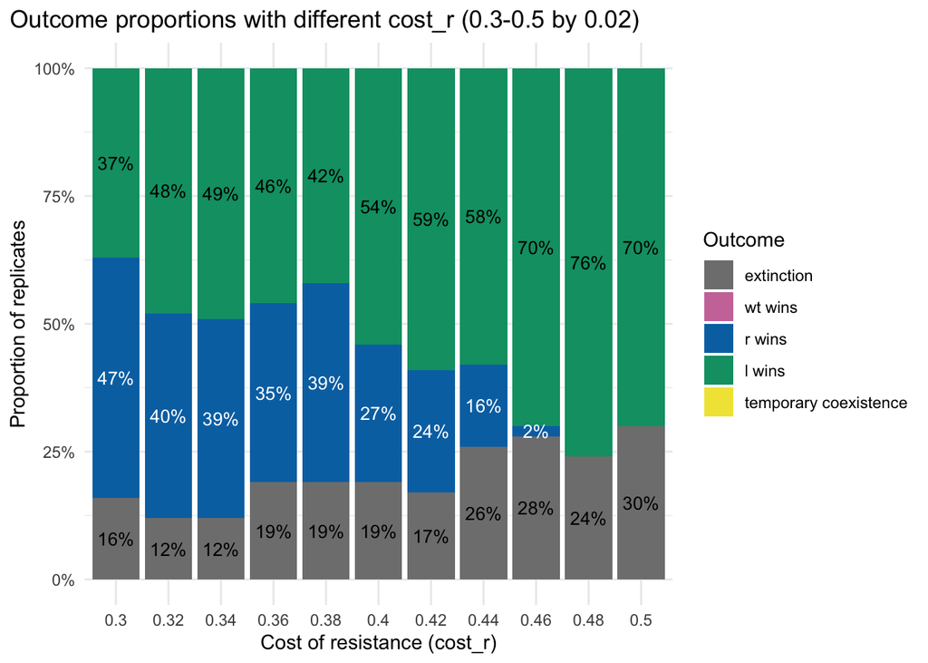

*Supplementary Figure 10: Barplot of outcome proportions for varying `cost_r` and fixed `induction_prob`. 100 simulations for each `cost_r` increasing from 0.3 to 0.5 (by steps of 0.02), a fixed `induction_prob`= 0.46 and set model parameters (List of variables and parameters in 2. Model and Methods) were run and the outcomes recorded. The percentage of each outcome for each value of `cost_r` is visualized.*

```
##      induction_prob wt    r l       p seed
## [1,]            0.6  0 1620 0 0.00000    2
## [2,]            0.6  0 1615 0 0.00000    3
## [3,]            0.6  0 1590 0 0.00000    4
## [4,]            0.6  0 1613 0 0.00000    5
## [5,]            0.6  0 1664 0 0.00000    6
## [6,]            0.6  0    0 0 4.08015    7
```

```
##   induction_prob wt    r l       p seed    outcome
## 1            0.6  0 1620 0 0.00000    2     r wins
## 2            0.6  0 1615 0 0.00000    3     r wins
## 3            0.6  0 1590 0 0.00000    4     r wins
## 4            0.6  0 1613 0 0.00000    5     r wins
## 5            0.6  0 1664 0 0.00000    6     r wins
## 6            0.6  0    0 0 4.08015    7 extinction
```

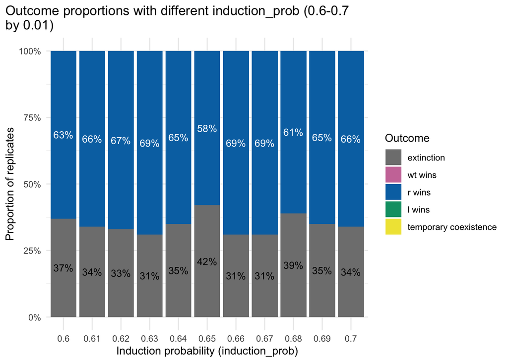

*Supplementary Figure 11: Barplot of outcome proportions for varying `induction_prob` and fixed `cost_r`. 100 simulations for each `induction_prob` increasing from 0.6 to 0.7 (by steps of 0.01), a fixed `cost_r` = 0.1 and set model parameters (List of variables and parameters in 2. Model and Methods) were run and the outcomes recorded. The percentage of each outcome for each value of `induction_prob` is visualized.*